SYSTEMATIC REVIEW

published: 29 October 2020

doi: 10.3389/fped.2020.516698

[figure not shown]

Frontiers in Pediatrics | www.frontiersin.org

1

October 2020 | Volume 8 | Article 516698

Edited by:

Po-Yin Cheung,

University of Alberta, Canada

Reviewed by:

Helmut Dietmar Hummler,

University of Ulm, Germany

David Tingay,

Royal Children’s Hospital, Australia

*Correspondence:

Erin V. McGillick

erin.mcgillick@hudson.org.au

Specialty section:

This article was submitted to

Neonatology,

a section of the journal

Frontiers in Pediatrics

Received: 20 December 2019

Accepted: 13 August 2020

Published: 29 October 2020

Citation:

Lambert CJ, Hooper SB, te Pas AB

and McGillick EV (2020) Improving

Newborn Respiratory Outcomes With

a Sustained Inﬂation: A Systematic

Narrative Review of Factors Regulating

Outcome in Animal and Clinical

Studies. Front. Pediatr. 8:516698.

doi: 10.3389/fped.2020.516698

Improving Newborn Respiratory

Outcomes With a Sustained Inﬂation:

A Systematic Narrative Review of

Factors Regulating Outcome in

Animal and Clinical Studies

Calista J. Lambert <sup>1</sup>, Stuart B. Hooper <sup>1,2</sup>, Arjan B. te Pas <sup>3</sup>and Erin V. McGillick <sup>1,2</sup>*

1 The Ritchie Centre Hudson Institute of Medical Research, Melbourne, VIC, Australia, 2 The Department of Obstetrics and

Gynaecology, Monash University, Melbourne, VIC, Australia, <sup>3</sup>Division of Neonatology, Department of Pediatrics, Leiden

University Medical Center, Leiden, Netherlands

Respiratory support is critically important for survival of newborns who fail to breathe

spontaneously at birth. Although there is no internationally accepted deﬁnition of a

sustained inﬂation (SI), it has commonly been deﬁned as a positive pressure inﬂation

designed to establish functional residual capacity and applied over a longer time

period than normally used in standard respiratory support (SRS). Outcomes vary

distinctly between studies and to date there has been no comprehensive investigation

of differences in SI approach and study outcome in both pre-clinical and clinical

studies. A systematic literature search was performed and, after screening, identiﬁed

17 animal studies and 17 clinical studies evaluating use of a SI in newborns compared

to SRS during neonatal resuscitation. Study demographics including gestational age,

SI parameters (length, repetitions, pressure, method of delivery) and study outcomes

were compared. Animal studies provide mechanistic understanding of a SI on the

physiology underpinning the cardiorespiratory transition at birth. In clinical studies, there

is considerable difference in study quality, delivery of SIs (number, pressure, length) and

timing of primary outcome evaluation which limits direct comparison between studies.

The largest difference is method of delivery, where the role of a SI has been observed

in intubated animals, as the inﬂation pressure is directly applied to the lung, bypassing

the obstructed upper airway in an apnoeic state. This highlights a potential limitation in

clinical use of a SI applied non-invasively. Further research is required to identify if a SI

may have greater beneﬁts in subpopulations of newborns.

Keywords: sustained inﬂation, newborn respiratory outcome, clinical trials, animal models, ventilation,

cardiorespiratory function, resuscitation and respiratory support

INTRODUCTION

The importance of providing respiratory support during neonatal resuscitation cannot be

overstated. Technological advances within this ﬁeld have signiﬁcantly improved survival for

newborns who either do not spontaneously breathe at birth or need support to maintain

spontaneous breathing, most commonly due to prematurity. Historically, these advances came at

Lambert et al.

Sustained Inﬂation: Systematic Narrative Review

the cost of ventilator-induced lung injury, a collection of

related lung injuries that lead to chronic lung disease (1, 2).

More recently, clinical practice has moved toward non-invasive

respiratory support delivered via a face mask to provide either

continuous positive airway pressure (CPAP) or intermittent

positive pressure ventilation (iPPV), which will be collectively

referred to as standard respiratory support (SRS). However, if this

approach fails to support neonatal respiratory function, invasive

intubation, and mechanical ventilation is required.

SRS is often insuﬃcient to support very preterm neonates

at birth. Preterm neonates often have poor respiratory eﬀort

at birth and as such are unable to fully aerate the lung. Pre-

clinical studies have shown that this leads to non-uniform lung

liquid clearance and increases the risk of hyperinﬂation injury

in aerated lung regions during subsequent breaths/inﬂations.

Given the rise in rates of prematurity globally and the life-long

morbidity of neonatal lung injury, novel neonatal ventilation

approaches have been investigated. This has led to the exploration

of non-conventional strategies of ventilation, such as a sustained

inﬂation (SI) (3). The use of a SI as a ventilation strategy in

apnoeic neonates at birth was informed by early observational

studies examining factors leading to functional respiratory

capacity (FRC) formation in asphyxiated neonates (4, 5).

Although there is no internationally accepted deﬁnition of a

SI, it has previously been deﬁned as a positive pressure inﬂation

applied over a longer time period than normally used in SRS. A

SI aims to improve the uniformity of lung aeration (6–12) and

the newborn cardiorespiratory transition (13, 14). A SI has not

been shown to reduce lung injury, with some pre-clinical studies

suggesting it may injure the lungs at high pressures (15, 16).

Despite many studies investigating the use of a SI in both

animal models and human neonates, there is considerable

variation in the use of the SI and newborn outcomes with recent

studies questioning the beneﬁts and safety of SI use clinically (17,

18). This narrative review aimed to synthesize the current animal

and clinical literature providing a SI to newborns in the delivery

room to gain a greater understanding of factors surrounding the

delivery of a SI and newborn cardiorespiratory outcomes.

SYNTHESIS OF CURRENT KNOWLEDGE

Search Strategy

A systematic search of the literature was conducted to identify

studies investigating the use of a SI in newborns in both animal

and clinical studies. OVID Medline, Embase and Scopus were

searched using the keywords “sustained,” “inﬂation,” “infant,

newborn, neonate,” and the Map term to Subject Heading (MeSH)

terms “infant, newborn,” “infant, premature,” “fetus,” “sheep,”

“rabbit,” and “animals, domestic” (CJL). All studies published

prior to April 2020 were included. Study titles and then abstracts

were screened, with eligibility for inclusion based on full text

assessment. Studies were included if they were original research

studies published in English and compared the use of SI in

newborns to either a SRS (CPAP or iPPV) or at least one other

intervention to provide respiratory support for the ﬁrst breaths

of life (i.e., stepwise PEEP). The reference lists of included studies

and review articles were examined to identify relevant articles not

captured by electronic search. The combined search strategies

yielded 723 studies, of which 34 were eligible for inclusion in

this review (see **Figure 1** for exclusion). Of these, 17 were animal

experimental studies and 17 were clinical trials. The review was

undertaken to highlight the inherent variability between and

to tease apart methodological approaches and ﬁndings between

the studies. This was conducted in the form of a narrative

review following the systematic literature search as it was not

appropriate to perform a meta-analysis due to heterogeneity

between studies (19). For clarity, when discussing studies in this

review all humans are referred to as neonates and animals are

referred to by the species. Where sentiments from both animals

and humans are discussed in combination, they are referred to

generally as newborns.

Tabulated Data

For each animal study, the publication characteristics (author,

year, and species), SI parameters (length, pressure, number

of SIs given, method of delivery) and experiment details

(aim, physiological parameters measured, and outcome) were

tabulated (**Table 1**). To facilitate comparison between animal

and human studies in terms of gestational age and phase

of lung development, animal gestational age at delivery was

converted to human gestational age (**Table 1**) (6, 23, 26). As

this review evaluates the eﬀect of a SI on functional as opposed

to anatomical lung diﬀerences, where appropriate comparison

between gestational age in relevant animal studies have been

converted relative to functional properties of the human lung

(**Table 1**) (6, 27, 28). As these studies investigated multiple

components of newborn physiology, the measured parameters

were broadly characterized into blood gases, non-invasive

oxygenation, lung mechanics, markers of blood ﬂow and pressure

(pulmonary and carotid artery), lung injury, and the use and type

of dynamic lung imaging for each study (**Table 1**).

For each clinical study, the study characteristics (author, year

and country of origin, study type), population characteristics

(sample size, gestational age mean, and range), SI and SRS

parameters (length, pressure, number of SIs given, type of

SRS given, method of delivery, indication for delivery) and

study outcomes (primary outcome, timing of primary outcome

measurement relative to birth and primary outcome result)

were tabulated (**Table 2**). The study measures and individual

outcomes have been tabulated from data reported in the original

publications. Reporting of overall study outcomes in text are

based on the authors’ interpretations of the overall original study

outcomes. Where applicable, Cochrane review data was extracted

to generate a relative risk (RR) and a 95% conﬁdence interval (CI)

for each included study (45). Where studies were not included

in the Cochrane review, a RR and CI was calculated from raw

data included in the original study authors’ publication. These

data were reported alongside authors ﬁndings (**Table 2**) and used

to create a Forest plot for risk of intubation and mechanical

ventilation to compare between studies (**Figure 2**) and also

to rank primary outcome timing evaluated relative to birth

(**Figure 3**). This was not possible for studies using continuous

variables to measure primary outcome.

Frontiers in Pediatrics | www.frontiersin.org

2

October 2020 | Volume 8 | Article 516698

Lambert et al.

Sustained Inﬂation: Systematic Narrative Review

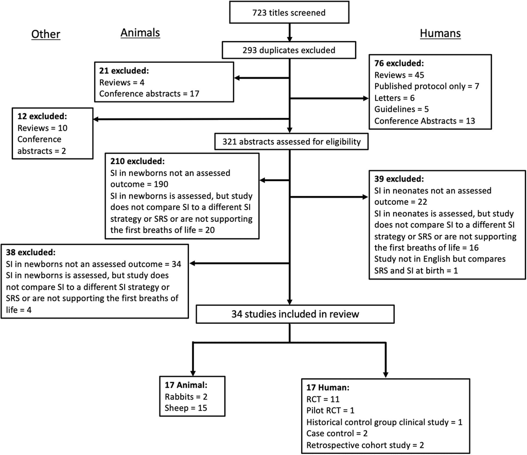

FIGURE 1 | Summary of literature search and selection of studies included in the current synthesis of studies in animal and clinical literature evaluating the use of a

sustained inﬂation on newborn cardiorespiratory outcome.

Investigating the Effect of Sustained

Inﬂation in Clinical and Experimental

Literature

Findings From Animal Studies

Relevant study demographics are reported in **Table 1** for the 17

included animal studies. These studies were published between

2009 and 2019. The large size of sheep makes them an

appropriate animal model for complex physiological studies, with

15 studies using sheep. However, the function of sheep lungs

is not consistent with anatomical maturity when compared to

human lungs, and so gestational age conversion from sheep

to human is based on similarity in functional maturity rather

than anatomical maturity (**Table 1**) (6, 27, 28). Two studies

used the smaller animal model of rabbits, which (1) have

similar anatomical/functional properties at a given gestational

age compared to humans and (2) are ideal for experiments using

synchrotron imaging to assess lung aeration and respiratory

mechanics at both the global and regional airway scale given

their smaller size. Relative to the lambs, the rabbit studies

have investigated outcomes after a relatively shorter duration

following SI and to date have not assessed markers of lung injury.

Conversely, only one observational study to date has investigated

dynamic mechanics during SIs in a lamb model (46). Despite

their diﬀerences, each animal model and investigative approach

provides important knowledge to understand the eﬀect of SIs on

newborn physiology.

There is a fundamental diﬀerence in the weight of sample

size and/or power calculation reporting considerations between

clinical and animal studies. While the sample size of animal

studies is powered to detect diﬀerences between groups in the

main outcome, just as clinical studies are, animal studies can also

minimize interacting variables and maximize treatment eﬀects

to identify diﬀerences between groups. Although this can limit

Frontiers in Pediatrics | www.frontiersin.org

3

October 2020 | Volume 8 | Article 516698

Lambert et al.

Sustained Inﬂation: Systematic Narrative Review

TABLE 1 | Animal studies investigating the effect of sustained inﬂation on newborn cardiorespiratory outcome.

Author

Year Published

Species

Primary

goal of

study

Equivalent

gestational age

range in

humans

based on

functional lung

development

(weeks)

Gestational

age mean

(days)

Length of

sustained

inﬂation

(seconds)

Maximum

Pressure

(cmH2O)

Number of

sustained

inﬂations

given

Method of

Intubation

SRS group

ventilation

Study aim

Parameters

measured

Outcome

regarding SI

Main ﬁndings

Reﬁne SI

delivery

Compare SI

strategies

Effect of SI on

physiology

Pre-viable

24-26

26-28

28-30

30-32

32-34

34-36

36-38

38-40

<15

16-30

31-45

46+

≤20

25

30

35

40

50

1

43

5

Stepwise PEEP

Oral

Tracheostomy

Not speciﬁed

iPPV

PEEP only

Experimental

groups only

Blood gases

NI Oxygenation

Lung mechanics

PA blood

pressure/ﬂow

CA blood

pressure/ﬂow

Lung Injury

Dynamic

lung imaging

Beneﬁts SI

No difference

Beneﬁts SRS

te Pas (7)

2009 Rabbits

28

G1

+

G2

G3

To test the optimum SI

length to optimize lung

recruitment

Synchrotron imaging

20 second SI is best for

lung recruitment but

improvements in ventilation

can be seen with a 10

second SI.

Sobotka

(14)

2011 Sheep

127

60

To determine whether a

sustained increase in

intrathoracic pressure

during an SI impedes

venous return

A longer (up to 1 min) SI

does not impede venous

return and actually

supports the transition at

birth.

Hillman (15) 2013 Sheep

128±1

Tidal volume group

PEEP group

To determine whether

SI reduces lung injury

compared to MV alone

in surfactant deﬁcient

lambs

SI itself causes mild

inﬂammation (at autopsy;

45 mins of life), but the

overall inﬂammatory effect

of MV was the same

regardless of whether an SI

was used.

Klingenberg

(13)

2013 Sheep

139±2

G1

G2

G2

G1

To test the 2010 ILCOR

guidelines using 5x3

second inﬂations an

effective lung

recruitment strategy

5x3 second inﬂations had a

similar outcome to iPPV

and inferior to 1x30 second

inﬂation.

Hillman (20) 2014 Sheep

126±1

Tidal volume group

PEEP group

To determine whether

SI has a better lung

injury proﬁle than MV in

surfactant treated

lambs

SI itself does not cause

inﬂammation, but the

inﬂammatory effect of MV

was the same regardless of

whether an SI was used.

Polglase

(21)

2014 Sheep

131

G1

G2: 15ml/kg

To determine whether a

volume limited

approach to SI superior

to the pressure limited

inﬂations commonly

used

EIT

Volume limited and

pressure limited

approaches to SI have

similar outcomes.

Tingay (8)

2014 Sheep

127

G1

G2: 10 breaths

G2

G1

G1

G2

To determine whether

stepwise PEEP is a

superior strategy to SI

for lung recruitment

EIT

Stepwise PEEP

Stepwise PEEP allowed

better oxygenation, lung

mechanics, regional

thoracic volume and lower

ventilator settings than SI.

Tingay (9)

2015 Sheep

127±1

G1

G2:<132 G3:<145

To determine whether it

is better to tailor the SI

to achieve lung aeration

rather than using a ﬁxed

SI time and pressure

EIT

Volume equilibrium

strategies have a better

lung mechanics and injury

proﬁle than both a 30

second SI and iPPV.

(Continued)

Frontiers in Pediatrics | www.frontiersin.org

4

October 2020 | Volume 8 | Article 516698

Lambert et al.

Sustained Inﬂation: Systematic Narrative Review

TABLE 1 | Continued

Author

Year Published

Species

Primary

goal of

study

Equivalent

gestational age

range in

humans

based on

functional lung

development

(weeks)

Gestational

age mean

(days)

Length of

sustained

inﬂation

(seconds)

Maximum

Pressure

(cmH2O)

Number of

sustained

inﬂations

given

Method of

Intubation

SRS group

ventilation

Study aim

Parameters

measured

Outcome

regarding SI

Main ﬁndings

Reﬁne SI

delivery

Compare SI

strategies

Effect of SI on

physiology

Pre-viable

24-26

26-28

28-30

30-32

32-34

34-36

36-38

38-40

<15

16-30

31-45

46+

≤20

25

30

35

40

50

1

43

5

Stepwise PEEP

Oral

Tracheostomy

Not speciﬁed

iPPV

PEEP only

Experimental

groups only

Blood gases

NI Oxygenation

Lung mechanics

PA blood

pressure/ﬂow

CA blood

pressure/ﬂow

Lung Injury

Dynamic

lung imaging

Beneﬁts SI

No difference

Beneﬁts SRS

Tingay (10)

2015 Sheep

131

G1

G2: 7m/kg tidal volume

over 5 minutes G3: 7ml/kg

tidal volume from birth

G1

1. To determine

whether SI is

superior to IMV

delivered quickly or

gradually

2. To determine

whether in IMV tidal

volume be reached

quickly or gradually

EIT

There were similar

outcomes between SI and

IMV.

In IMV, gradually increasing

tidal volume over 5 minutes

resulted in less recruitment

and worse oxygenation

than those that reached

tidal volume in 0.4 seconds.

Sobotka

(22)

2016 Sheep

139±2

G1 G2

G2

G1

To determine the effect

of a SI on the carotid

blood ﬂow and cerebral

vascular integrity of

asphyxiated newborns

Likely secondary to high

tidal volume rather than SI

Although SI supports the

cardiopulmonary transition

at birth, it is associated with

cerebral vascular injury in

asphyxiated lambs at birth,

however, this was thought

to be due to higher tidal

volume after the SI rather

than the SI itself as lower

tidal volumes after SI had

similar injury proﬁle to iPPV.

te Pas (23)

2016 Rabbits

27 (1), 29 (2) or 30 (3)

G2 + G3

G1

G2 = 28 G3 = 27

G1 = 37

To ﬁnd the most

effective SI pressure

and duration for lung

recruitment at various

gestational ages

Synchrotron imaging

The more immature the

kitten, the higher the

starting pressure required

and the longer the SI

required to achieve a set

inﬂation volume.

Tingay (12)

2016 Sheep

127±2

G2

G3: 10 breaths

G3

G2

G2

G3

To compare stepwise

PEEP with SI and iPPV

on lung mechanics and

injury and gas exchange

EIT

Stepwise PEEP

Stepwise PEEP has a

better lung mechanics and

injury proﬁle than both SI

and iPPV.

Tingay (11)

2016 Sheep

127

G2

G3: 10 breaths

G3

G2

G2

G3

To describe the

relationship between

antenatal steroids,

exogenous surfactant

and lung recruitment

strategies

EIT

Stepwise PEEP

Stepwise PEEP improved

compliance compared to

control SRS and SI

irrespective of surfactant or

antenatal steroid status

(Continued)

Frontiers in Pediatrics | www.frontiersin.org

5

October 2020 | Volume 8 | Article 516698

Lambert et al.

Sustained Inﬂation: Systematic Narrative Review

TABLE 1 | Continued

Author

Year Published

Species

Primary

goal of

study

Equivalent

gestational age

range in

humans

based on

functional lung

development

(weeks)

Gestational

age mean

(days)

Length of

sustained

inﬂation

(seconds)

Maximum

Pressure

(cmH2O)

Number of

sustained

inﬂations

given

Method of

Intubation

SRS group

ventilation

Study aim

Parameters

measured

Outcome

regarding SI

Main ﬁndings

Reﬁne SI

delivery

Compare SI

strategies

Effect of SI on

physiology

Pre-viable

24-26

26-28

28-30

30-32

32-34

34-36

36-38

38-40

<15

16-30

31-45

46+

≤20

25

30

35

40

50

1

543

Stepwise PEEP

Oral

Tracheostomy

Not speciﬁed

iPPV

PEEP only

Experimental

groups only

Blood gases

NI Oxygenation

Lung mechanics

PA blood

pressure/ﬂow

CA blood

pressure/ﬂow

Lung Injury

Dynamic

lung imaging

Beneﬁts SI

No difference

Beneﬁts SRS

McCall (6)

2017 Sheep

118-120 (1), 123-125 (2), 127-129 (3), 132-134 (4), 139-141 (5)

1 &2: 180 seconds; 3: 120 seconds 4: 150

seconds; 5: 90 seconds

G1-5

G1-5

To describe the

relationship between

gestational age and the

time to stable lung

aeration

EIT

Gestational age exerted a

signiﬁcant and linear,

inﬂuence on the volumetric

behavior of the lung during

an SI with longer SI

durations required to reach

optimal aeration in the most

preterm lambs.

Tingay (24)

2017 Sheep

127±1

G2: 36-132

(median:72)

G3: 10 breaths

G3

G2

G2

G3

To compare optimized

SI, stepwise PEEP and

iPPV

EIT

Similar outcomes are

achieved with optimized

SI and stepwise PEEP.

Tingay (25)

2019 Sheep

126±2

G2:

<180

G3:

150-180

G3 (14-20)

G2

G2

G3

To compare efﬁcacy of

ventilation strategy to

improve lung function

after surfactant

administration

EIT

Stepwise

PEEP

There was a greater

responsiveness to

surfactant in lambs that

received stepwise PEEP

strategy.

Tingay (16)

2019 Sheep

125±1

G2:

<180

G3:

170-180

G3 (14-20)

G2

G2

G3

To compare the effect

of gradual vs. rapid

aeration on lung volume

and injury markers

EIT

Stepwise

PEEP

Stepwise PEEP group had

greater compliance at

30-90 minutes after

delivery and lower

expression of some lung

injury markers than SI

group.

Individual squares are shaded to indicate gestational age of animal studies relative to comparative functional properties of the lung in the human neonate. Cumulative squares were shaded to indicate the length and pressure of sustained

inﬂation where applicable. Where multiple groups were included within the study, the SI strategy used for each group is listed, prefaced with a G for group. Lung mechanics includes tidal volume, dynamic respiratory system compliance,

airway pressures, and alveolar arterial difference in oxygen (AaDO2). Lung injury included any markers of lung injury, most commonly protein content in the broncho-alveolar lavage ﬂuid and expression of messenger ribonucleic acid

(mRNA) markers in lung tissue. Markers of cardiorespiratory transition included evaluation of both blood pressure and ﬂow in the pulmonary artery (PA) and carotid artery (CA). Non-invasive (NI) oxygenation includes pre-ductal oxygen

saturations (pre-ductal SpO2) and near-infrared spectroscopy (NIRS). Dynamic lung imaging includes electrical impedance tomography (EIT) and simultaneous synchrotron phase contrast X-ray imaging and plethysmography. Stepwise

PEEP was listed in the outcomes regarding SI column when the beneﬁt conferred from an SI strategy applied to stepwise PEEP only. Sheep, term = 147 days. Rabbit, term = 32 days. cmH2O = centimeters of water; IMV, intermittent

mandatory ventilation; iPPV, intermittent positive pressure ventilation; MV, mechanical ventilation; PEEP, positive end expiratory pressure; SI, sustained inﬂation; SRS, standard respiratory support. Deﬁned in all studies using stepwise

PEEP as: begin at 6 cmH2O, increase after 10 breaths by 2 cmH2O until 20 cmH2O, then decrease by 2 cmH2O until 6 cmH2O except (8), where commencing PEEP was 4 cmH2O, increase after 10 breaths by 2 cmH2O until 20

cmH2O, then decrease by 2 cmH2O until 6 cmH2O. Summary of study demographics and variables in delivery of intervention to newborn animals and outcome in studies comparing sustained inﬂation to standard respiratory support

strategy. Studies are presented in chronological order.

Frontiers in Pediatrics | www.frontiersin.org

6

October 2020 | Volume 8 | Article 516698

Lambert et al.

Sustained Inﬂation: Systematic Narrative Review

TABLE 2 | Clinical studies investigating the effect of a sustained inﬂation on neonatal respiratory outcome.

Study

Year published

Location of trial

Type of trial

Sample size & SRS

ventilation

Gestational age

range (weeks)

Mean gestational

age (weeks)

Length of

SI (seconds)

Pressure (cmH2O)

Maximum number

of SIs

Criteria for giving

the next SI

Method of delivering

inﬂations

Primary Outcome

Timing of primary

outcome

ITT analyses

Outcome regarding SI

Study

results:

SI

vs. SRS group

23-25

25-27

28-30

30-32

32-34

34-36

0-5

10

15

16-20

15

20

25

432130

Cyanosis

Inadequate

breathing/apnoea

Bradycardia

Face Mask

NP tube

Nasal Prongs

T-piece

Bag-Mask

Intubation

0-24hsr of life

48-72 hrs

1 week

Discharge/36 CGA

Beneﬁts SI

No difference

Beneﬁts SRS

Harling (29)

2005

UK

RCT

26 SI

26 1 x 2s

breath

27 SI

28 1 x 2s

breath

Required for BALF

Pulmonary

inﬂammation

(cytokines in BALF)

x

No difference in IL-6,

IL-1β, IL-10 or TNFα

(p=0.5-0.86)

Lindner (30)

2005

Germany

RCT

31 SI

30 iPPV

(Outcome

regarding SI

27 SI

26.7 iPPV

1st

2nd

3rd

*Not stated

Intubation and

mechanical

ventilation

61% v. 70%

(p=0.59)

RR: 1.02 [CI: 0.68-1.53]

te Pas (31)

2007

Netherlands

RCT

104 SI +

PEEP

103 iPPV only

(delayed

PEEP)

29.4 SI

29.5 iPPV

1st

2nd

SI

iPPV

Intubation and

ventilation

37% v. 51% (p=0.04)

RR#: 0.72 [CI: 0.53–

0.99]

Lista (32)

2011

Italy

Historical

control group

clinical study

89 SI

119 iPPV

28.1 SI

28.1 iPPV

2nd

1st

1st

Need for

intubation and

mechanical

ventilation during

hospital stay

N/A

51% v. 76% (p<0.0001)

RR#: 0.67 [CI:

0.53-0.84]

Grasso (33)

2015

Italy

Case-

controlled

78 SI

78 iPPV

30.4 SI

30.5 iPPV

*Not explicitly

stated

Need for

intubation and

mechanical

ventilation during

hospitalization was

selected

N/A

14% vs 55% (p<0.001)

RR#: 0.26 [CI:

0.14-0.46]

Lista (34)

2015

Italy

RCT

148 SI

143 nCPAP

26.8 SI

26.8 nCPAP

Need for

intubation and

mechanical

ventilation

53% v. 65% (p = 0.04)

RR: 0.82 [CI:

0.68-1.00]

(Continued)

Frontiers in Pediatrics | www.frontiersin.org

7

October 2020 | Volume 8 | Article 516698

Lambert et al.

Sustained Inﬂation: Systematic Narrative Review

TABLE 2 | Continued

Study

Year published

Location of trial

Type of trial

Sample size & SRS

ventilation

Gestational age

range (weeks)

Mean gestational

age (weeks)

Length of

SI (seconds)

Pressure (cmH2O)

Maximum number

of SIs

Criteria for giving

the next SI

Method of delivering

inﬂations

Primary Outcome

Timing of primary

outcome

ITT analyses

Outcome regarding SI

Study

results:

SI

vs. SRS group

23-25

25-27

28-30

30-32

32-34

34-36

0-5

10

15

16-20

15

20

25

432130

Cyanosis

Inadequate

breathing/apnoea

Bradycardia

Face Mask

NP tube

Nasal Prongs

T-piece

Bag-Mask

Intubation

0-24hsr of life

48-72 hrs

1 week

Discharge/36 CGA

Beneﬁts SI

No difference

Beneﬁts SRS

Schwaberger

(35)

2015

Austria

Pilot RCT

20 SI

20 CPAP

32.1 SI

32.1 CPAP

Cerebral blood

volume (CBV) and

cerebral tissue

oxygenation index

(cTOI)

x

cTOI: No difference (p

not given)

CBV: Raw comparison

data not given. Stated

that SI was steadier than

CPAP which rose then

dropped (p = 0.051)

Mercadante

(36)

2016

Italy

RCT

93 SI

92 iPPV

36+6

35.2 SI

35.2 iPPV

Need for any form

of respiratory

support

x

10.7% v. 8.7% (p=0.64)

RR: 1.98 [CI: 0.18 –

21.44]

El-Chimi (37) 2017

Egypt

RCT

57 SI

55 iPPV

31.1 SI

31.3 iPPV

1st

2nd

3rd

SI

iPPV

Need for

intubation and

mechanical

ventilation

x

24.6% v. 45.5%

(p=0.017)

RR: 0.54 [CI:

0.32-0.93]

Jiravisitkul

(38)

2017

Thailand

RCT

43 SI

38 iPPV

29 SI

29 iPPV

Percentage of

inspired oxygen

required at 5 and

10 minutes

following birth

5 min: 48% v. 68%

(p=0.004)

10 min: 28% v. 47%

(p<0.001)

Ngan (39)

2017

Canada

RCT

76 SI

86 iPPV

(terminate

early)

28 SI

28 iPPV

2nd if etCO2 >20mmHg

1st & 2nd if etCO2 <20mmHg

Bronchopulmonary

dysplasia

23% vs 33%, (p=0.09)

RR: 1.20 [CI: 0.96-1.49]

Abd

El-Fattah

(40)

2017

Egypt

RCT

80 SI

(20 G1;

20 G2;

20 G3;

20 G4) 20

nCPAP

29.6 G1

29.7

G2 29.3

G3 29.7

G4 29.4

nCPAP

G2, G4

G1, G3

G3, G4

G1, G2

Need for

intubation and

ventilation in the

delivery room.

x

25% (G1) v. 20% (G2-4)

v. 55% (nCPAP)

p=0.002

RR#: 0.39 [CI:

0.22-0.69

(Continued)

Frontiers in Pediatrics | www.frontiersin.org

8

October 2020 | Volume 8 | Article 516698

Lambert et al.

Sustained Inﬂation: Systematic Narrative Review

TABLE 2 | Continued

Study

Year published

Location of trial

Type of trial

Sample size & SRS

ventilation

Gestational age

range (weeks)

Mean gestational

age (weeks)

Length of

SI (seconds)

Pressure (cmH2O)

Maximum number

of SIs

Criteria for giving

the next SI

Method of delivering

inﬂations

Primary Outcome

Timing of primary

outcome

ITT analyses

Outcome regarding SI

Study

results:

SI

vs. SRS group

23-25

25-27

28-30

30-32

32-34

34-36

0-5

10

15

16-20

15

20

25

432130

Cyanosis

Inadequate

breathing/apnoea

Bradycardia

Face Mask

NP tube

Nasal Prongs

T-piece

Bag-Mask

Intubation

0-24hsr of life

48-72 hrs

1 week

Discharge/36 CGA

Beneﬁts SI

No difference

Beneﬁts SRS

Buyuktiryaki

(41)

2018

Turkey

Retrospective

cohort study

113 SI

102 nCPAP

*Not stated,

but

comparable

between

groups.

nCPAP

SI

nCPAP

Need for

mechanical

ventilation

N/A

25.7% v. 56.9%

(p<0.001)

RR#: 0.45 [CI:

0.32-0.64]

Kirpalani (18) 2019

International

RCT

215 SI

211 iPPV

(terminated

early)

25.3 SI

25.3 iPPV

1st

2nd

Death or BPD at

36 weeks CGA as

a combined

outcome

63.7% v. 59.2% (p =

0.34)

RR(#): 1.08 [CI: 0.93-

1.25]

Hunt (42)

2019

England

RCT

30 SI (G1)

30 5x3s

breaths (G2)

30.6 SI

29.7 5x3s

G2

G1

G1 & 2

Duration of

mechanical

ventilation in those

that received

mechanical

ventilation

19.5 hours v. 48 hours

(p=0.03)

La Verde (43) 2019

Italy

Prospective

case-

controlled

22 SI

22 iPPV

30 SI

30 iPPV

Matched

adrenomedullin

concentration

blood and urine

N/A

No difference in

adrenomedullin between

groups or over 24 hours

(p>0.05)

Kanaan (44)

2020

France

Retrospective

cohort study

72 SI +

stepwise

PEEP

91 5 x 3s

breaths

28 SI

28 5 x 3s

breaths

1st

2nd

3rd and 4th

1st, 2nd and 3rd

4th

Need for

intubation and

mechanical

ventilation

N/A

57% v. 79% (p<0.05)

Squares are cumulatively shaded to indicate gestational age. Where squares are not shaded, information regarding this parameter was not described in the study. Where multiple SIs are given at different lengths or pressures, these are

indicated in white text.

BALF, bronchoalveolar lavage ﬂuid; CGA, corrected gestational age; CI, conﬁdence interval; cmH2O, centimeters of water; IL, interleukin; ITT, intention-to-treat; NP, nasopharyngeal; RCT, Randomized control trial; RR, relative risk

calculated from Cochrane review (45). RR#, relative risk calculated by authors from incidence of intubation and mechanical ventilation in SI and SRS groups reported in individual studies; RR(#), relative risk calculated by authors from

incidence of intubation and mechanical ventilation in SI and SRS groups however met criteria for inclusion into a Cochrane review; SI, sustained inﬂation; TNFα, tumor necrosis factor alpha. Summary of study demographics and variables

in delivery of intervention to neonates and outcome in studies comparing sustained inﬂation to their respective standard respiratory support group. Studies are presented in chronological order.

Frontiers in Pediatrics | www.frontiersin.org

9

October 2020 | Volume 8 | Article 516698

Lambert et al.

Sustained Inﬂation: Systematic Narrative Review

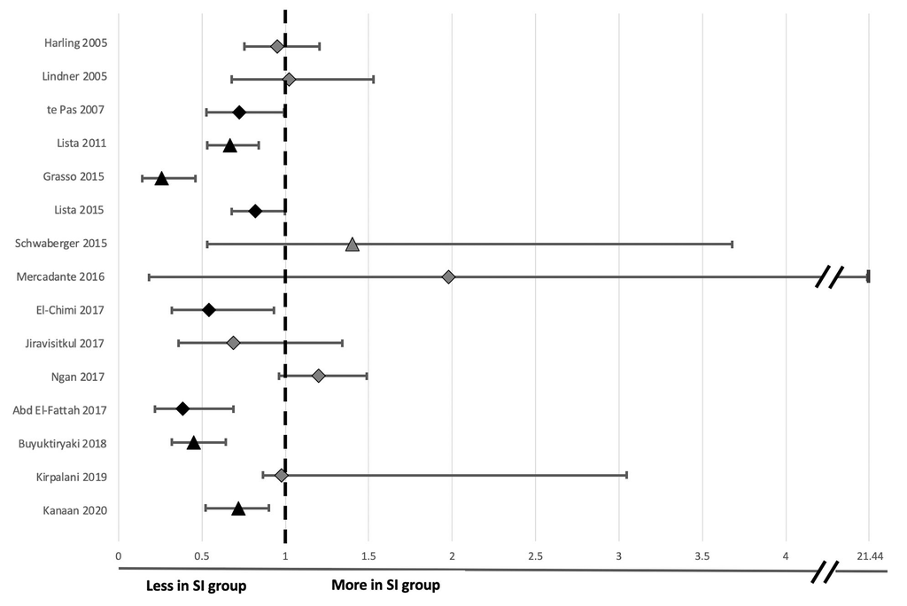

except Kirpalani et al. at which is listed at 48 h following birth for consistency with other studies. Relative risk and conﬁdence interval values were extracted from the

2020 Cochrane review where possible (45), or manually calculated (31–33, 40, 41, 44). Diamonds indicate RCTs and triangles indicate non-RCT study designs. Black

indicates data sets resulting in signiﬁcant differences and light gray indicates data sets reporting no signiﬁcant difference in risk of intubation between the sustained

inﬂation and relative control group within individual studies.

the focus of the study to diﬀerences in the primary outcome in a

highly controlled setting, it does avoid the use of inappropriately

large animal numbers, which is one of the primary tenets of

animal experimentation. As such, not all publications include a

description of power calculations. In the animal studies included

in this review, all studies reported sample sizes in each group.

Speciﬁc power calculations were stated in methods or other

justiﬁcation in 8 studies (6, 9, 11, 12, 16, 23–25). One study

included a partial statement (20) to justify smaller sample sizes

for some groups, but no justiﬁcation of the overall group sizes.

While 8 studies did not report power calculation or sample

size justiﬁcation (7, 8, 10, 13–15, 22, 47). However, as the

animal studies reported signiﬁcant diﬀerences in at least one

of their main outcomes, it is evident that the studies were

powered appropriately to detect diﬀerences under the deﬁned

experimental conditions.

The overall goal of the animal studies was to reﬁne the

delivery of SI (7 studies), compare the eﬀects of SI with a

diﬀerent ventilation strategy (6 studies) or examine the eﬀect

of SI combined with other factors upon newborn physiology

(4 studies). There was variability in the gestational age range

evaluated between studies, however, all studies investigated

outcomes

in

premature

newborns

with

uncomplicated

pregnancies with the exception of 2 studies investigating

outcome in a birth asphyxia model.

Studies diﬀered in the type of SI strategies used, with 10 using

variations on pressure-based strategies (7, 8, 10–15, 20, 22) and 8

using a volume-based strategy (6, 9, 10, 16, 21, 23–25). Six studies

also included a stepwise positive end expiratory pressure (PEEP)

group in addition to a SI group which have been explored in this

review as they fulﬁlled the inclusion criteria (8, 11, 12, 16, 24, 25).

While both SI and stepwise PEEP approaches are pressure-

based interventions aimed at improving lung aeration, they target

diﬀerent phases of the respiratory cycle.

All animal studies either compared multiple SI ventilation

strategies (a longer or physiological SI to shorter or ﬁxed SI =

2 studies, stepwise PEEP strategy to SI = 6 studies, SI parameters

in various gestational age cohorts = 2 studies, other SI group

comparisons = 3 studies), or to a SRS group (iPPV = 10 studies,

iPPV and PEEP alone as separate control groups = 2 studies;

Frontiers in Pediatrics | www.frontiersin.org

10

October 2020 | Volume 8 | Article 516698

Lambert et al.

Sustained Inﬂation: Systematic Narrative Review

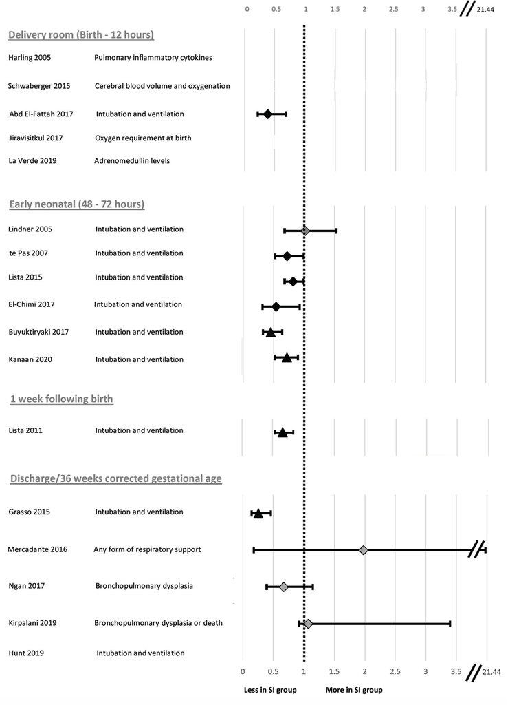

FIGURE 3 | Forest plot of relative risk and 95% conﬁdence intervals for primary outcomes reported in clinical studies evaluated in Table 2. The individual studies have

been ranked based on timing of primary outcome evaluation. Relative risk and conﬁdence interval values were extracted from the 2020 Cochrane review where

possible (45) or manually calculated (18, 31–33, 40, 41, 44). Diamonds indicate RCTs and triangles indicate non-RCT study designs. Black indicates data sets

resulting in signiﬁcant differences and light gray indicates data sets reporting no signiﬁcant difference in risk of primary outcome in SI compared to SRS. Where the

primary outcome was a continuous variable, relative risk was unable to be calculated and a value has not been reported.

Frontiers in Pediatrics | www.frontiersin.org

11

October 2020 | Volume 8 | Article 516698

Lambert et al.

Sustained Inﬂation: Systematic Narrative Review

**Table 1**). These protocols diﬀered in the length, pressure and

number of SIs given. Within the pressure-based protocols, two

studies used multiple (3–5 repeats), short (3–5 s) inﬂations, 10

studies used a single ﬁxed SI (5–60 s) and 7 studies used a

single SI with length determined by degree of lung inﬂation

(physiological SI; 21–306 s). With regards to pressure, the 2

studies that used multiple, short inﬂations both used pressures

of 30–35 cmH2O. The ﬁxed SI studies commonly used pressures

of 35–50 cmH2O while volume-based studies used temporarily

higher pressures to create the SI (21). The physiological-based

SI studies used pressures between 27 and 40 cmH2O and most

of the stepwise PEEP protocols began at 6 cmH2O, climbing up

to a maximum of 20 cmH2O before descending to 6–8 cmH2O.

Of the animal studies that included a SRS group, either a PEEP

of 5 cmH2O (5 studies) (7, 10, 13, 14, 22) or 8 cmH2O (7

studies) (9, 12, 15, 16, 20, 24, 25) was used. In contrast with the

clinical studies, all animal studies administered the SI to sedated

newborn animals that were either intubated orally (9 studies) or

via tracheostomy (3 studies) to control for eﬀects of spontaneous

breathing, as their primary focus was investigating the eﬀect of

SI on the newborn cardiorespiratory physiology. Five studies did

not report their method of intubation, however based on other

studies by the same authors, it could be assumed that these lambs

were intubated orally.

The advantage of using animal models is to permit the use

of invasive methods to comprehensively investigate the eﬀects

of SI on newborn physiology. The animal studies had broad

aims primarily focused on investigating the cardiorespiratory

transition that were measured at discrete time points from

birth to between 7 min and 8 h post-delivery (**Table 1**). Blood

gases (12 studies), non-invasive oxygenation (10 studies), lung

mechanics (17 studies), pulmonary blood pressure and/or ﬂow

(1 study), carotid artery pressure and/or ﬂow (7 studies), lung

injury (9 studies) and dynamic lung imaging using either

simultaneous synchrotron phase contrast X-ray imaging and

plethysmography (2 studies) or electrical impedance tomography

(10 studies) were used to assess the cardiorespiratory transition

using either two (5 studies), three (1 study), four (3 studies), ﬁve

(5 studies), or six (3 studies) outcomes in total. Eight studies

included evaluation of derived indices of gas exchange such

as AaDO2 to provide information regarding blood gases and

lung mechanics.

The animal studies found an overall positive eﬀect of a SI

compared to iPPV and PEEP alone on short term physiological

outcomes (Beneﬁts SI, physiological SI or stepwise PEEP = 11

studies; No diﬀerence = 4 studies; Beneﬁts SRS = 2 studies;

**Table 1**). More speciﬁcally, 6 studies have shown that a single

20–30 s inﬂation improves markers of the cardiorespiratory

transition compared to shorter inﬂations given either alone or

repeated up to three times. Stepwise PEEP has been reported

by 5 studies to improve lung mechanics compared to a single

SI (8, 11, 12, 16, 25), improve lung compliance and aeration in

response to surfactant and cause less lung injury (25), however

there is lack of data as to whether the prolonged inﬂation time of

up to 5 min impedes venous return to the heart. Pressure-based

SI strategies of up to 45 s have a similar lung injury proﬁle to iPPV

(15, 20) and do not impede venous return (14).

Findings From Human Studies

Relevant study demographics are reported in **Table 2** for the

17 human studies included in this systematic narrative review.

Of the included studies, 11 were randomized control trials

(RCTs), one was a historical control group clinical study, one

was a pilot RCT, two were case-control studies, and two were

retrospective cohort studies). Studies were published between

2005 and 2020. As discussed in the recent Cochrane review

investigating outcomes of sustained vs. standard inﬂations during

neonatal resuscitation, RCTs had varying levels of bias in their

randomization, all were unblinded for initial data collection and

only half the studies blinded the researchers who analyzed trial

endpoints (45). All RCTs were designed as superiority studies. All

but one RCT reported power calculations. Those that reported

power calculations were adequately powered apart from three

studies, all of which were underpowered due to early termination

of the study. For 2 studies, early termination occurred due to

slow enrolment of participants (30, 39). Data for the remaining

study showed an association between SI and early death at <48 h

(18). The study that did not report a power calculation (37)

was likely underpowered based on the number of participants of

studies with a similar primary outcome (31, 34). Compared to

the SI treatment group, the relative SRS groups were deﬁned as

ventilation strategy where the initial breath was more than 2 s

(3 studies). It is important to consider the variation within the

SRS groups regarding PEEP, as although iPPV given via a T-piece

resuscitator is able to provide PEEP, iPPV delivered via bag-

mask ventilation does not. Therefore, there may be diﬀerences

in eﬃciency of respiratory support in the SRS groups between

studies to support the newborn’s lung function.

Gestational ages ranged from 23<sup>+</sup><sup>0</sup>-36<sup>+</sup><sup>6</sup>weeks with mean

gestational ages ranging 25.3–35.2 weeks. One study had a

diﬀerence in the mean gestational age between groups of more

than 7 days (29). With respect to degree of prematurity, 13

studies evaluated outcomes in extremely premature neonates

(<28 weeks gestation at birth.), 14 studies evaluated outcomes

in very premature neonates (<32 weeks gestation at birth), and

5 studies evaluated outcomes in moderate-late preterm neonates

(32–36 weeks gestation at birth.). While a number of studies

examined outcomes in a range of diﬀerent gestational ages, only

1 study published results stratiﬁed by gestational age (44).

All clinical studies used pressure-based approaches to

administer the SI, however, there was much variation in the times,

pressures and number of SIs delivered. All studies delivered SIs

for at least one duration (5 s = 3 studies; 10 s = 5 studies; 15 s

= 13 studies; 20 s = 2 studies). Four studies administered at

least two SIs of diﬀerent durations. One study directly compared

diﬀerent SI strategies to each other. No studies stratiﬁed results

based on the number of SIs delivered.

The SI pressure applied ranged from 15 to 30 cmH2O (15

cmH2O = 1 study; 20 cmH2O = 6 studies; 25 cmH2O =

14 studies; 30 cmH2O = 4 studies). There were diﬀerences

between studies in the number of SIs delivered, with 2 studies

administering 1 SI, 10 studies administering 2 SIs, 3 studies

administering three SIs and 1 study administering 4 SIs. One

study did not state how many SIs were administered (40).

Frontiers in Pediatrics | www.frontiersin.org

12

October 2020 | Volume 8 | Article 516698

Lambert et al.

Sustained Inﬂation: Systematic Narrative Review

Increases in pressure on subsequent SIs were used in studies

administering multiple SIs. Criteria for administering multiple

SIs was based on a combination of one (3 studies), two (4

studies), three criteria (4 studies), or not stated (3 studies).

These included cyanosis (4 studies), bradycardia (10 studies) and

irregular breathing/apnoea (11 studies).

All clinical studies administered SIs via either face mask

(13 studies), nasopharyngeal airway (3 studies), nasal prongs (1

study) or an unspeciﬁed, non-invasive method (1 study) unless

intubation was required on clinical grounds as per the study

protocol. One study used either a nasopharyngeal airway or face

mask depending on the trial center (18).

The

primary

outcome

varied

greatly

between

studies.

Respiratory insuﬃciency as indicated by the need for intubation

and mechanical ventilation was the main outcome of 10 studies

and presence of bronchopulmonary dysplasia was examined

by 2 studies. Duration of mechanical ventilation, pulmonary

inﬂammation, adrenomedullin levels in blood, and urine as a

biomarker of pulmonary and vascular change during transition,

death, oxygen requirement in the delivery room or markers of

cerebral perfusion and oxygenation were all primary outcomes of

1 study each. One study listed need for any form of respiratory

support as the primary outcome, however, it is unclear what

interventions were considered respiratory support. One study

had dual primary outcomes, however, the remaining studies each

had one primary outcome. There was considerable variability

within and between groups regarding the timing of primary

outcome evaluation (**Figure 3**), including early markers in the

delivery room or within 24 h of life (5 studies), early neonatal

or later, either prior to discharge or at 36 weeks corrected

Seven studies used intention-to-treat (ITT) analyses, however

the short time between the respiratory support intervention

provided, and outcome measurement mean that, although not

explicitly stated, it is likely a further 4 studies were analyzed using

ITT principles.

Eight studies showed that SI caused a statistically signiﬁcant

decrease in intubation and mechanical ventilation rates (**Table 2**;

**Figure 2** presents RR and 95% CIs for risk of endotracheal

intubation ranked by study year where provided in text or able

to be calculated from available data) compared to their respective

that those given SI required shorter durations of intubation

and mechanical ventilation and another showed less need for

supplemental oxygen at 5 and 10 min post birth.

The largest RCT to date showed that although there was no

diﬀerence in death or bronchopulmonary dysplasia (BPD) at 36

weeks between the SI and SRS group as a primary outcome, there

was a statistically signiﬁcant increase in death in the ﬁrst 48 h of

life in neonates given an SI (18). This led to early termination of

the trial, thereby limiting deﬁnitive conclusions about the use of

SIs in extremely preterm infants.

There were no signiﬁcant diﬀerences between the SRS and

SI groups in terms of markers of lung injury (29), cerebral

tissue oxygenation (35), need for any form of respiratory support

BPD as indicated by need for supplemental oxygen at 36 weeks

(39) or adrenomedullin concentration in blood and urine (43).

However, the studies investigating cerebral tissue oxygenation

and development of BPD were not adequately powered to

detect these diﬀerences. When the studies are ranked by timing

of need for mechanical ventilation at birth (**Figure 3**), the

most signiﬁcant eﬀect of SI was within 48–72 h post-birth.

Nevertheless, a lack of diﬀerence in outcome in some studies

indicates that a SI does not oﬀer improved outcomes compared

to the SRS interventions.

DISCUSSION

This systematic narrative review explores newborn SI studies

in both animals and humans. In this synthesis, we have

built upon previous meta-analyses to compare and contrast

the diﬀerent factors that inﬂuence SI delivery and outcomes

in order to gain a more comprehensive analysis of these

factors (17, 45, 48). In selecting studies for this review, no

assessment of methodological quality was applied to any of

the preclinical or clinical studies, and evidence grade was

not used as a ﬁlter in the design to facilitate the broadest

possible interpretation of the literature. Our tables include

detailed information extracted from included studies to highlight

strengths, limitations and diﬀerences between study designs and

outcomes. A more comprehensive discussion of limitations and

biases in SI meta-analysis literature has recently been discussed

(17, 45).

Animal models have allowed complex physiology surrounding

the transition from fetal to newborn life to be investigated

(**Table 1**). Clinical studies investigated primary outcomes related

to death, respiratory, and cerebral function (**Table 2**). In clinical

studies, we identiﬁed large diﬀerences in the way SIs and

SRS were administered, which contribute to the heterogeneity

observed in study outcomes. These include diﬀerences in

pressure, time, number of SIs delivered, the type of SRS used

and whether PEEP was used, and if respiratory support (SI or

SRS) was only given to neonates who had insuﬃcient respiratory

eﬀort at birth (rescue breaths), or if respiratory support was

given to all neonates regardless of whether insuﬃcient respiratory

eﬀort was observed (prophylactic breaths) (**Figures 4A,B**). A

recent Cochrane review on the use of SIs found no signiﬁcant

diﬀerences between SI and SRS (45). The largest multi-center

clinical trial to date found an increased rate of early death (<48 h

post birth) in neonates who received SI, however there was no

eﬀect on rate of death at discharge or BPD (18). It is clear there

is need for a greater understanding of the factors regulating the

success of SI given the heterogeneity between the large clinical

studies and the smaller clinical trials and animal studies. This is

best gained from animal studies due to invasive testing required

to determine these factors. Together these comparisons allow

a greater understanding of the multiple factors inﬂuencing SI

eﬀectiveness and provide valuable insights to target future work

in this area.

Frontiers in Pediatrics | www.frontiersin.org

13

October 2020 | Volume 8 | Article 516698

Lambert et al.

Sustained Inﬂation: Systematic Narrative Review

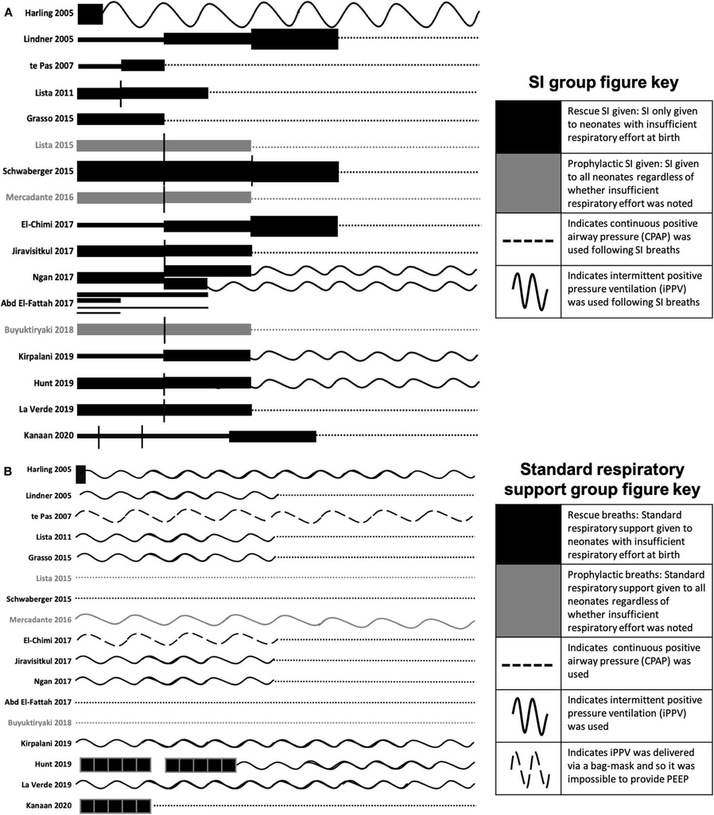

FIGURE 4 | SI and subsequent respiratory ventilation protocols for the included studies (A) and SRS ventilation protocols (B). The length of the line indicates the

length of the SI and the thickness of the line indicates the pressure (1 cm = 0–5 s, 2 cm = 6–10 s, 4 cm = 11–15 s, 6 cm = 16–20 s; 1 pt = 15 cmH2O, 6 pt = 20

cmH2O, 14 pt = 25 cmH2O, 26 pt = 30 cmH2O). Where multiple SIs of the same pressure were given, vertical black lines separate each SI. Black lines indicate where

the SI was only given to babies noted to have insufﬁcient respiratory effort at birth. Gray lines indicate where SI was given to all babies regardless of whether

insufﬁcient respiratory effort was noted. Following SIs, dotted lines indicate continuous positive airway pressure was used, wavy lines indicate that intermittent positive

pressure ventilation was used, dashed wavy lines indicate that intermittent positive pressure ventilation was delivered via bag-mask and so it was impossible to

provide PEEP. To aid interpretation of the graph, neonates who did not respond to SI and subsequent continuous positive airway pressure or intermittent positive

pressure ventilation have not been included as all studies further resuscitated and intubated neonates for intermittent mechanical ventilation as required. For Harling et

al. the black line indicates a 2 s inﬂation. For te Pas et al. PEEP was not commenced in the control group until arrival in the neonatal intensive care unit (NICU) whilst

PEEP was used throughout in the SI group. For Ngan et al. subsequent to the 1st SI, the length of the second SI was determined end tidal CO2. For El Fattah et al.

four SI groups were included with various lengths and pressures of the SIs as per the graph. For Hunt and Kanaan et al. the black boxes indicate 5 × 2–3 second

inﬂations. For Kanaan et al. ventilation protocol following SI and 5 × 3 s inﬂations are unclear, but it is noted that neonates were transferred to the NICU on either

CPAP or NIV, so CPAP has been used in the graphs.

Frontiers in Pediatrics | www.frontiersin.org

14

October 2020 | Volume 8 | Article 516698

Lambert et al.

Sustained Inﬂation: Systematic Narrative Review

Factors for Delivery of SI

SI Ventilation Strategy

Research into SI use in newborn resuscitation has investigated

two strategies: (1) pressure-based approaches, where the SI

is given based on a standard and pre-determined pressure

with length either ﬁxed or variable length depending on lung

inﬂation; (2) volume-based approaches, where the SI is given on

a predetermined tidal volume and length, with pressure adjusted

to reach that tidal volume. Some studies combined approaches

by using a tailored volume-based approach to determine the

optimum pressure and length of a pressure-based approach (9,

23). By far, the most research exists for pressure-based strategies,

Pressure-based strategies with an adequate length (>10 s) and

pressure (>15 cmH2O) are demonstrated in animal studies to

improve aeration and support the cardiorespiratory transition

(7, 14). However, the clinical studies suggest that SI use did not

reduce the need for intubation and mechanical ventilation in two

meta-analyses (17, 45).

Volume-based studies have only been used in pre-clinical

animal studies to date (6, 9, 10, 16, 21, 24, 25). No speciﬁc

guidelines exist regarding optimum volume delivery during SI,

however early studies used a large volume initial breath (0–15

mL/kg) for a ﬁxed pressure and duration (10, 47). Delivering a

pure volume-based SI may have a similar outcome to a pressure-

based SI, with a study in preterm lambs showing no diﬀerence

in lung mechanics, arterial and cerebral oxygenation, blood

pressure nor lung injury markers (21). While similar eﬀects were

observed when SIs were tailored by lung volume within the same

study (21), it is important to recognize that the mechanical state

of the preterm lung at birth should be considered, particularly

with regard to liquid vs. air-ﬁlled lung and uniformity of aeration.

Further studies developed the use of a more physiological-

based SI whereby a longer initial breath at a stable pressure

and volume per breath was delivered, allowing the delivery of

an individualized, larger volume of air due to the duration of

the breath. This was devised following the understanding that

every animal has unique ventilatory requirements and that the

risk of over or underinﬂating the lungs present with a ﬁxed

volume strategy may be ameliorated with a physiological SI. All

physiological-based SI studies to date use electrical impedance

tomography (EIT) to achieve optimal lung mechanics. These

studies have revealed large variations in the time taken to

reach the optimum delivered volume between animals of a

similar gestational age, however there is a trend to animals at

younger gestational ages requiring longer duration breaths to

reach the optimum lung volume (6, 10). A physiological-based

SI may result in more uniform lung aeration and improved

lung mechanics, however no diﬀerences have been observed

between a physiological-based SI and pressure-based SI in terms

of lung injury, oxygenation and markers of the cardiorespiratory

transition (6, 9, 16, 25).

SI Length

In humans, 13 studies support the use of a 15 s SI. It is likely

that this length has been chosen as 2015 ILCOR guidelines

recommend 2–3 s inﬂations given ﬁve times simultaneously,

leading to the assumption that a single 10–15 s SI may be

equivalent and appropriate for clinical use (3, 13). A 10 s inﬂation

is the minimum duration demonstrated to generate a statistically

signiﬁcant diﬀerence between those given SI and iPPV (31).

However, the conclusion that a 10 s SI is statistically diﬀerent to

iPPV may have been confounded by the use of PEEP. In this study

(31), SI was given via a T-piece, allowing PEEP to be administed

and received early nCPAP in the delivery room, whereas the SRS

group received iPPV alone via a bag-mask making it impossible

to apply PEEP and did not receive nCPAP until arrival to the

neonatal intensive care unit. Therefore, the beneﬁt in the trial

may have been due to all or one of the three components of the

early support intervention group (**Figures 4A,B**).

In animal models, longer inﬂations of 20 s inﬂations are most

commonly used. Use of this length was based on a landmark

paper early in SI research that showed that a 20 s inﬂation

improved lung mechanics more than a 5 or 10 s SI (7). However,

20 s was the longest SI investigated in that study, raising the

possibility that a longer SI could be even more eﬀective (7).

Recently, the same group showed that the SI length and pressure

required to reach target tidal volume at diﬀerent gestational ages

is higher than 20 s and trends toward an increase with earlier

gestational ages in rabbits (23). These ﬁndings were conﬁrmed

by a similar study in sheep, however a longer median SI duration

was used (6). The use of a 30 s SI has been investigated in 2 sheep

studies and may be more beneﬁcial compared to short SIs (≤5 s),

but this has not been directly compared to a 20 s SI (9, 11–13, 22).

The maximum length of a SI used to ventilate any animal in any

study is 5 min, with a lower median SI length, which when given

as an individually tailored regime, may ventilate the lungs more

evenly and cause less lung injury than a shorter SI (6, 9). The

study administering the longest SI duration investigated the eﬀect

of gestational age on time to achieve lung aeration and not clinical

outcome (6). Studies aiming to describe clinically translatable

outcomes typically used a SI duration of <3 min. It is likely

that the ideal SI time in humans is at least 20 s, with neonates

at younger gestational ages likely to beneﬁt from a longer SI

secondary to poor lung compliance due to incomplete lung liquid

clearance in an immature lung (6, 23).

SI Pressure

The 2015 ILCOR guidelines recommend an initial inﬂation

a pressure of 20–25 cmH2O for premature neonates and 30

cmH2O for term neonates for iPPV (3). Importantly the pressure

needed to aerate the ﬂuid-ﬁlled lung in neonates requiring

resuscitation is greater than the air-ﬁlled lung, hence, after the

initial breaths lower inﬂation pressures may be needed as the

lungs aerate and compliance increases. This is reﬂected in the

studies as all, but one clinical study used pressures of 20–

30 cmH2O (**Table 2**). Animal studies on average used higher

pressures, but it is unclear whether the diﬀerences are due to

diﬀerences in respiratory mechanics between species. While the

original SI studies used a SI of 35 cmH2O (7, 14), subsequent

studies have up to 50 cmH2O, which may reﬂect diﬀerent

experimental conditions and equipment (**Table 1**). There is no

evidence-based reason for diﬀerences between the pressures

used in animal and human studies reported. In sheep, inﬂating

pressures should not exceed 40 cmH2O, as using 50 cmH2O

causes mild inﬂammation that is not present when 40 cmH2O

is used (15, 20). One study directly compared the optimum

pressure used to inﬂate lungs at various gestational ages in

a rabbit model and suggested that the optimum pressure for

extremely premature lungs was 37 cmH2O, very premature

lungs was 28 cmH2O and moderately premature lungs was 27

cmH2O (23). This is consistent with the knowledge that earlier

gestational age is proportional to decreasing lung compliance

secondary to poor lung liquid clearance in apnoeic neonates.

In addition, the pressure reaching the lung during non-invasive

respiratory support may be impaired by upper airway (glottis)

patency, preventing the pressure delivered reaching the lungs,

particularly in newborns who are apnoeic (49). It also suggests

that the lower inﬂating pressures recommended for premature

neonates by ILCOR guidelines are unlikely to be high enough

to achieve uniform lung aeration, however this needs to be

balanced against the potential for increased lung injury (16, 50).

From these studies, it can be determined that (1) higher inﬂating

pressures than what are currently recommended are required

for premature neonates depending on gestational age and (2)

that these pressures should not exceed 40 cmH2O. Despite

the observations from animal studies, these pressures must be

validated in clinical trials before they can be applied to clinical

management guidelines to prevent harm by overdistention, non-

uniform aeration or lung injury.

Administering Multiple/Repeated SIs

Fourteen human studies repeated SIs, whereas in animal studies

repetition was only performed if the SI was ≤5 s, giving a similar

total duration of SI to that used in single SI studies (**Table 2**).

Four of these studies were performed to test recommendations

given by the 2010 European guidelines that a 3 s SI should be

delivered 5 times (13, 22, 42). Two animal studies found that

this short, repetitive ventilation strategy was similar to iPPV and

may be worse than a single 30 s SI in physiological measures

of the neonatal transition (13, 22). Two clinical studies found

that a short, repetitive ventilation strategy resulted in statistically

signiﬁcant higher rates of neonates requiring intubation and

longer duration of mechanical ventilation than SI (42, 44). All

experiments fail to compare outcomes between the number of

repetitions of SIs at an adequate length and pressure. Sub-group

analyses were not performed in any of the human studies based

on the number of SIs given, therefore it is diﬃcult to infer the

optimum number of times SI should be repeated.

Stepwise PEEP Ventilation Strategy

Stepwise PEEP is a ventilation strategy that aims to improve

alveolar recruitment and aeration with normal tidal inﬂations

during ascending and descending PEEP levels. Stepwise PEEP

studies suggest improved lung mechanics, less lung injury and

better response to surfactant compared to a ﬁxed pressure-based

SI strategy (8, 11, 12, 16, 25) and a similar or better eﬀect than a

physiological-based SI (16, 24). One study has been performed in

humans to date and combined an SI and stepwise PEEP strategy

with a maximum PEEP of 15 cmH2O (44). In the context of this

review it is important to consider the physiological diﬀerence in

ventilation approaches when comparing SI and stepwise PEEP

maneuvers. The diﬀerences include (i) large diﬀerences in the

duration (minutes) of the maneuvers, when the lung is exposed

to elevated airway pressures, (ii) while inﬂation times are not

prolonged during stepwise PEEP and are consistent with that

used during SRS, mean airway pressures are elevated, (iii) while

these approaches target diﬀerent components of the respiratory

cycle, the SI assumes that the expiratory phase is unnecessary

because the lungs are liquid-ﬁlled and gas exchange cannot

occur, and (iv) the inﬂating pressure during stepwise PEEP is the

same or lower than SRS groups. It is clear that the relationship

between pressure and time in these interventions requires

greater interrogation toward optimizing the most physiological

beneﬁcial approach for the newborn.

There is lack of data as to whether the prolonged inﬂation

time of up to 5 min impedes pulmonary blood ﬂow and venous

return to the heart. Some may argue that oscillating pressures

between PIP and PEEP may reduce the impact of an SI on

pulmonary blood ﬂow and venous return. However, it has been

observed in lambs that, during positive pressure ventilation

pulmonary blood ﬂow is reduced once PEEP levels increase to

8 cmH2O or higher (51). Pressure-based SI strategies showed a

similar lung injury proﬁle to SRS (15, 20) and did not impede

venous return (14). Many lamb studies have investigated the

eﬀects of a pressure-based SI on cardiovascular parameters and

found no signiﬁcant eﬀects, with 1 study (14) showing that a

pressure-based SI facilitated the increase in pulmonary blood

ﬂow. While it is important to recognize that the eﬀects of diﬀerent

SI interventions on pulmonary blood ﬂow was not assessed in

the rabbit studies, it is diﬃcult to envisage why they would

respond diﬀerently to lambs. Those studies focused exclusively

on lung function but used similar pressures at either a similar

or shorter duration than the lamb studies. When evaluating the

eﬀects of higher pressures and changes in PEEP on pulmonary

blood ﬂow it is important to consider the physiological diﬀerence

between initiation directly at birth in a liquid ﬁlled lung

vs. investigating pressure recruitment in an already aerated

or partially aerated lung. The cardiovascular consequences of

pressure-based maneuvers on the newborn lung is currently less

well understood. However, it is important to consider the integral

relationship between pressure and time targeted in respiratory

support strategies to ensure that they maximize the beneﬁts

on improving lung aeration and oxygenation compared to risk

of injury.

Effect of SI on Newborn Physiology

Requirement for Mechanical Ventilation

Ten human studies used the primary outcome of requirement

for intubation and mechanical ventilation (**Table 2**). Six of these

studies showed that neonates who received SI were signiﬁcantly

less likely to require intubation and mechanical ventilation

and one showed signiﬁcantly shorter durations of mechanical

ventilation in intubated neonates (31–34, 37, 40, 42, 44). The

time of assessment of intubation and mechanical ventilation as

an outcome varied between studies, ranging from the delivery

room to 1 week after birth (**Figure 3**). However, in the largest

study to date examining the most premature cohort of neonates,

no diﬀerences were found in need for intubation and mechanical

ventilation (18). A possible reason for these diﬀerences is that

intubation and mechanical ventilation were in, on average,

older premature neonates given prophylactic rather than rescue

breaths (**Figure 4A**). It is likely that for those neonates given

prophylactic SIs, a portion of them may have been spontaneously

breathing and therefore, the success of providing SI non-

invasively by facemask was less likely to be impaired by a

closed larynx preventing the inﬂation pressure reaching the lungs

(52, 53). However, the trial looking at the oldest cohort of

premature neonates showed no superiority of a SI compared to

SRS, suggesting there is a “goldilocks range” of neonates in whom

SI may have a beneﬁcial eﬀect because (1) they have suﬃcient

respiratory drive to breathe spontaneously thus opening their

larynx and allowing the SI to ventilate the lung and (2) their lungs

are immature enough that they are unable to clear lung liquid

and uniformly aerate the lung with the assistance of CPAP or

iPPV alone. It is possible that this gestational age range is 28–

34 weeks gestation at birth as statistically signiﬁcant reductions

in intubation and mechanical ventilation rates have been mostly

described within this age range (31–34, 37, 40, 41, 44). Outside of

this age range, no statistically signiﬁcant diﬀerences in intubation

and mechanical ventilation rates in studies providing rescue

breaths have been described (18, 36), or in the 2 meta-analyses

investigating all gestational groups as a whole (17, 45).

Cardiorespiratory Transition

Lung

aeration

triggers

the

initiation

of

the

newborn

cardiorespiratory transition by clearing lung liquid, which in

turn reduces pulmonary vascular resistance and increases blood

ﬂow through the lungs (54). Two human studies have indirectly

measured the cardiorespiratory transition (38, 43). The ﬁrst,

underpowered study of 81 neonates demonstrated that oxygen

requirement was signiﬁcantly lower in neonates receiving SI than

CPAP at both 5 and 10 min after birth, indirectly indicating that

SI supports the cardiorespiratory transition (38). The second

study did not demonstrate a diﬀerence in adrenomedullin levels

between groups at 24 h, and the authors suggested no diﬀerence

between SI and iPPV on pulmonary and vascular changes during

transition (43).

Fourteen of the included animal studies investigated the eﬀect

of SI on the cardiorespiratory transition at birth (6, 8–14, 21, 22,

24, 25, 55, 56). Stepwise PEEP, pressure-based and physiological-

based SIs have been shown in multiple studies to improve lung

mechanics compared to iPPV alone. In combination with PEEP,

a SI creates FRC by facilitating more uniform lung aeration than

iPPV or CPAP (7, 16). This is reﬂected in the higher pre-ductal

oxygen saturations (SpO2) and lower partial pressure of carbon

dioxide (PaCO2) in animals who received a SI, meaning that

the lung is more eﬃcient at exchanging gases when a SI is used

(10). A SI has also been shown in animal studies to increase

pulmonary blood ﬂow following birth compared to iPPV, likely

due to increased eﬃciency in lung aeration required to trigger

the decrease in pulmonary vascular resistance, in turn increasing

the amount of blood ﬂow available for oxygenation by the lungs

(14, 22).

Lung Injury

All strategies of ventilation have been shown to induce lung

injury compared to uninﬂated lungs (16, 57). Three human

studies used lung injury (via inﬂammatory markers or BPD) as

a primary outcome and suggested that there were no statistically

signiﬁcant diﬀerences between SI and iPPV groups (18, 29, 39). A

fourth, underpowered, prospective RCT investigated lung injury

as a secondary outcome (40). This study suggested that neonates

who received a SI for 20 s at 20 cmH2O had signiﬁcantly higher

lung injury markers immediately after intubation, however, these

became similar to CPAP lung injury markers 12 h following

intubation (40). It has been suggested that a repetitive SI strategy

may be associated with increased risk of air leak development

in the lungs, e.g., pneumothorax or pulmonary interstitial

emphysema, however this is yet to be fully investigated (58).

Of the animal studies that analyzed lung injury, all but two

suggested that the injury proﬁles between appropriate SI and

iPPV are similar (8–10, 20, 21, 25). However, as the early response

genes used to assess lung injury have an activation time course

of only 60–90 min (57), it is possible that no diﬀerence was

detected because lung tissue was collected up to 2 h after delivery.

One study suggested that stepwise PEEP resulted in less lung

injury than both SI and iPPV in the presence of surfactant and

exogenous steroids in all groups (25). The second study was

primarily focused on investigating lung injury and suggested

that a SI caused more regional lung injury than either iPPV or

stepwise PEEP in the youngest population of lambs (16). The

SI in this study was delivered at 35 cmH2O until 10 s after the

lung volume signal plateaued or for a maximum of 180 s. This

study reported that even though the overall lung gas volumes

(end-expiratory volumes and Vt) were similar, lung aeration

was not uniform with greater aeration occurring in the non-

dependent lung of the SI animals and dependent lung in stepwise

PEEP animals. While this ﬁnding is not consistent with previous

studies that have used imaging to measure the uniformity of lung

aeration following a SI (1, 7), it is consistent with their ﬁnding of

increased expression of injury markers following a SI in rabbits.

However, in the context of lung injury, it is necessary to consider

(i) the timing of the intervention provided, (ii) the pressure

delivered and (iii) the timing of outcome evaluation relative

to the intervention. Indeed, as the time course of activation

of these early lung injury markers has a relatively short time

window (15–90 min) (57), measuring tissue levels of these injury

markers at 90 min after the intervention makes it diﬃcult to

assess whether the observed lung injury was directly related to

the SI or to events that occurred after the SI. As the uniformity

of lung aeration attributed to an SI can be lost during the ﬁrst

few inﬂations following the SI (7), the eﬀect of a SI on post-SI

ventilation needs further investigation. Indeed, it is necessary to

understand diﬀerences in management both within and between

study groups following the intervention in order to be able to

attribute eﬀects to the SI directly or ongoing post-intervention

ventilation management itself as a potential source of lung injury

(57). More recently, the advancement of proteomics approaches

to assess lung injury have been investigated in preterm lambs

receiving ventilation support for as little as 15 min up to 90 min

(59), however these techniques have not been used in any studies

investigating SI use to date.

Neither of the studies investigating birth asphyxia analyzed

lung injury (13, 22), but have shown an increase in brain injury,

thought to be due to greater and more rapid recovery from severe

asphyxia. It is important to consider that while in immature lungs

SI has a similar injury proﬁle to iPPV, the eﬀect of SI in other

obstetric subpopulations with pathological causes of apnoea at

birth is unknown. In future studies investigating SI use, there

are a range of considerations that should be taken into account,

speciﬁcally use of the appropriate power to detect changes in lung

injury markers, adequate sampling regimens to reliably detect

heterogeneous injury, the timing of lung injury marker collection

and the relevance of the investigated pathways.

Brain Injury

Two studies have examined brain injury as an outcome of SI

(22, 35). One pilot RCT assessed cerebral oxygenation and blood

volume changes and found a statistically signiﬁcant diﬀerence

in blood volume patterns in the ﬁrst 15 min after birth, but no

diﬀerence in cerebral oxygenation (35). The authors suggested

that this ﬁnding demonstrated that SI led to cerebral venous

stasis due to impaired venous return to the heart. However, their

ﬁndings that the SI group maintained a more consistent blood

volume overall than the CPAP group may be attributable to

cerebral autoregulation rather than cerebral venous stasis.

While SI does not cause cerebral venous stasis, in combination

with a high tidal volume it has been observed to cause increased

extravasation of plasma proteins at the blood-brain barrier in

birth asphyxiated lambs compared to those given multiple, short

inﬂations or iPPV (22). It must be noted that in this case

of compromised, asphyxic lambs the authors attributed the

increased extravasation to high tidal volume rather than the SI

itself, as a SI in combination with a low tidal volume prevented

any extravasation. It may therefore be concluded that while SI

facilitates improved lung aeration and more consistent cerebral

oxygenation, any respiratory interventions that followed must

have a relatively low tidal volume (e.g., <7 mL/kg) to prevent

brain injury through disruption of the blood-brain barrier. As

this is the only study to investigate the eﬀects of SI on asphyxic

newborn lamb brains, further work is required to understand the

mechanisms of action of SIs in compromised neonates.

Mortality

A recent RCT investigating the use of SI compared to iPPV

on death or BPD among extremely preterm infants was ceased

prematurely due to increased early mortality (within 48 h of life)

in the neonates receiving SI as a prespeciﬁed safety variable (18).

However, the absolute numbers of neonatal deaths were small (16

neonates in SI vs. 3 neonates in iPPV; 7.4 vs. 1.4%, respectively).

Sixty-eight percentage of early deaths occurred in neonates aged

23–24 weeks gestation at birth and the statistically signiﬁcant

diﬀerence present at <48 h of life were no longer present at 36

weeks corrected gestational age.

There was no pattern regarding cause of death identiﬁed by

the study authors and they noted that it could be a chance

ﬁnding (18). It is important to consider that death was observed

in the most vulnerable population of neonates (23–24 weeks

gestation), with high baseline mortality rates [∼35–65% (60)],

due to the numerous potential complications these neonates face

from extreme prematurity. This study highlights the importance

of considering the impact timing of evaluation has on the overall

primary outcome (**Figure 3**).

CONCLUSION

This review has provided a comprehensive synthesis of factors

inﬂuencing outcomes in both animal and clinical studies

investigating the use of SI in newborns. However, we have

highlighted many gaps in the literature, including the optimum SI

pressure, time, method of delivery and number of repetitions as

well as the eﬀect of a SI on the brain, heart and other organs. The

heterogeneity in newborn populations, SI administration and the

timing of primary outcome makes direct comparison between

clinical studies diﬃcult (**Table 2**, **Figures 3**, **4**).

Overall, some clinical studies have shown beneﬁts of a

SI relative to SRS to reduce the need for intubation and

mechanical ventilation in neonates aged 28–34 weeks gestation

at birth. It is possible that the optimum pressure of SI increases

with increasing prematurity, with neonates born at earlier

gestations requiring higher ventilation pressures. However, 2

recent systematic reviews and meta-analyses suggested that a SI

should not currently be routinely used for preterm infants at

birth (17, 45). The ﬁndings of the most comprehensive RCT in

extremely premature neonates (<28 weeks gestation at birth) for

early neonatal death within 48 h have raised concerns regarding

the safety of SI use in the delivery room (18). The speciﬁc cause

of death of these neonates and whether it was related to SI

is unknown.

Given the inability to demonstrate long term beneﬁt and as

safety concerns have been raised, the use of SI in human neonates

should be limited to clinical trials. However, this suggestion

does not discriminate between intubated and non-intubated

infants and therefore, assumes that these diﬀerent subgroups of

infants will respond similarly to a SI. Unfortunately, intubated

infants have not been speciﬁcally examined, despite all preclinical

evidence coming from intubated newborns and suggesting that

they may beneﬁt from a SI applied after intubation directly to

the lung.

Taken together, the research indicates that while animal

studies are required to inform the design of scientiﬁcally sound

clinical studies, care should be taken to accurately translate the

scientiﬁc ﬁndings. Animal studies have provided understanding

of the complex physiology underpinning the eﬀect of SI on the

newborn cardiorespiratory transition. While the positive beneﬁts

of SIs in animal models have not been duplicated in clinical

studies, the automatic assumption that this is an example of

where humans respond diﬀerently to animals is problematic.

Instead, we should ﬁrst ask why and what was done diﬀerently

between the human and animal studies. In this instance, the

answer is potentially straight forward, in that intubation is likely

to be more eﬃcient at transmitting the SI directly onto the lung

as it bypasses the upper airway. Indeed, recent studies in animals

have shown that the upper airway, particularly closure of the

larynx, can block the airway and prevent air from entering the

lungs (52). This highlights the need to encourage spontaneous

breathing, so the larynx will open, to improve the success of non-

invasively administered positive pressure ventilation, including a

SI (52).

Another factor to consider is the eﬃcacy of a SI in newborns

with pathological causes of apnoea at birth and neonatal

subpopulations with abnormal lung compliance and respiratory

mechanics (e.g., congenital lung malformations, lung hypoplasia,

infection, asphyxia). Although these populations were excluded

from the clinical studies captured in this systematic search

analysis, they may beneﬁt greatly from SI, particularly if it is

necessary to intubate them.

It is clear that future studies are required to optimize the

factors related to SI use identiﬁed in this review and to close

gaps in knowledge. Evaluation of the underlying physiology is

required to identify the safest and most eﬀective respiratory

support to support the transition to neonatal life.

DATA AVAILABILITY STATEMENT

All datasets generated/analyzed for this study are included in the

article/**Supplementary Material**.

AUTHOR CONTRIBUTIONS

CL, SH, AtP, and EM were responsible for the conception, design

of the project, were involved in analysis, interpretation of the

data, and drafted the article. CL and EM were each involved in

data acquisition. All authors contributed to the ﬁnal version.

FUNDING

SH was supported by an NHMRC Principal Research Fellowship

(APP1058537). AtP was the recipient of a Vidi grant, The

Netherlands Organization for Health Research and Development

(ZonMw), part of the Innovational Research Incentives Scheme

Veni-Vidi-Vici (NWO-Vidi 2015/2016). EM was supported by

a Monash University Bridging Postdoctoral Fellowship (BPF17-

0066) and a NHMRC Peter Doherty Biomedical Early Career

Fellowship (APP1138049).

SUPPLEMENTARY MATERIAL

The Supplementary Material for this article can be found

online

at:

https://www.frontiersin.org/articles/10.3389/fped.

2020.516698/full#supplementary-material

REFERENCES

1. te Pas AB, Siew M, Wallace MJ, Kitchen MJ, Fouras A, Lewis RA, et al.

Establishing functional residual capacity at birth: the eﬀect of sustained

inﬂation and positive end-expiratory pressure in a preterm rabbit model.

Pediatr Res. (2009) 65:537–41. doi: 10.1203/PDR.0b013e31819da21b

2. Donn

SM,

Sinha

SK.

Can

mechanical

ventilation

strategies

reduce

chronic

lung

disease?

Semin

Neonatol.

(2003)

8:441–8.

doi: 10.1016/S1084-2756(03)00124-6

3. Wyllie J, Bruinenberg J, Roehr CC, Rüdiger M, Trevisanuto D, Urlesberger

B. European resuscitation council guidelines for resuscitation 2015: Section 7.

Resuscitation and support of transition of babies at birth. Resuscitation. (2015)

95:249–63. doi: 10.1016/j.resuscitation.2015.07.029

4. Boon

AW,

Milner

AD,

Hopkin

IE.

Lung

expansion,

tidal

exchange, and formation of the functional residual capacity during

resuscitation

of

asphyxiated

neonates.

J

Pediatr.

(1979)

95:1031–6.

doi: 10.1016/S0022-3476(79)80304-2

5. Vyas H, Milner AD, Hopkin IE, Boon AW. Physiologic responses

to

prolonged

and

slow-rise

inﬂation

in

the

resuscitation

of

the

asphyxiated

newborn

infant.

J

Pediatr.

(1981)

99:635–9.

doi: 10.1016/S0022-3476(81)80279-X

6. McCall KE, Waldmann AD, Pereira-Fantini P, Oakley R, Miedema M,

Perkins EJ, et al. Time to lung aeration during a sustained inﬂation at

birth is inﬂuenced by gestation in lambs. Pediatr Res. (2017) 82:712–20.

doi: 10.1038/pr.2017.141

7. te Pas AB, Siew M, Wallace MJ, Kitchen MJ, Fouras A, Lewis RA, et al.

Eﬀect of sustained inﬂation length on establishing functional residual capacity

at birth in ventilated premature rabbits. Pediatr Res. (2009) 66:295–300.

doi: 10.1203/PDR.0b013e3181b1bca4

8. Tingay DG, Bhatia R, Schmolzer GM, Wallace MJ, Zahra VA, Davis PG.

Eﬀect of sustained inﬂation vs. stepwise PEEP strategy at birth on gas

exchange and lung mechanics in preterm lambs. Pediatr Res. (2014) 75:288–

94. doi: 10.1038/pr.2013.218

9. Tingay DG, Lavizzari A, Zonneveld CE, Rajapaksa A, Zannin E, Perkins E,

et al. An individualized approach to sustained inﬂation duration at birth

improves outcomes in newborn preterm lambs. Am J Physiol Lung Cell Mol

Physiol. (2015) 309:1138–49. doi: 10.1152/ajplung.00277.2015

10. Tingay DG, Polglase GR, Bhatia R, Berry CA, Kopotic RJ, Kopotic

CP, et al. Pressure-limited sustained inﬂation vs. gradual tidal inﬂations

for resuscitation in preterm lambs. J Appl Physiol. (2015) 118:890–7.

doi: 10.1152/japplphysiol.00985.2014

11. Tingay DG, Rajapaksa A, McCall K, Zonneveld CEE, Black D, Perkins E, et

al. The interrelationship of recruitment maneuver at birth, antenatal steroids,

and exogenous surfactant on compliance and oxygenation in preterm lambs.

Pediatr Res. (2016) 79:916–21. doi: 10.1038/pr.2016.25

12. Tingay DG, Rajapaksa A, Zonneveld CE, Black D, Perkins EJ, Adler A, et

al. Spatiotemporal aeration and lung injury patterns are inﬂuenced by the

ﬁrst inﬂation strategy at birth. Am J Respir Cell Mol Biol. (2016) 54:263–72.

doi: 10.1165/rcmb.2015-0127OC

13. Klingenberg C, Sobotka KS, Ong T, Allison BJ, Schmolzer GM, Moss

TJ, et al. Eﬀect of sustained inﬂation duration; resuscitation of near-term

asphyxiated lambs. Arch Dis Child Fetal Neonatal Ed. (2013) 98:222–7.

doi: 10.1136/archdischild-2012-301787

14. Sobotka KS, Hooper SB, Allison BJ, Te Pas AB, Davis PG, Morley

CJ, et al. An initial sustained inﬂation improves the respiratory and

cardiovascular transition at birth in preterm lambs. Pediatr Res. (2011) 70:56–

60. doi: 10.1203/PDR.0b013e31821d06a1

15. Hillman NH, Kemp MW, Noble PB, Kallapur SG, Jobe AH. Sustained

inﬂation at birth did not protect preterm fetal sheep from lung injury. Am J

Physiol Lung Cell Mol Physiol. (2013) 305:446–53. doi: 10.1152/ajplung.00162.

2013

16. Tingay DG, Pereira-Fantini PM, Oakley R, McCall KE, Perkins EJ, Miedema

M, et al. Gradual aeration at birth is more lung protective than a sustained

inﬂation in preterm lambs. Am J Respir Crit Care Med. (2019) 200:608–16.

doi: 10.1164/rccm.201807-1397OC

17. Foglia EE, te Pas AB, Kirpalani H, Davis PG, Owen LS, van Kaam AH,

et al. Sustained inﬂation vs standard resuscitation for preterm infants: a

systematic review and meta-analysis. JAMA Pediatr. (2020) 174:e195897.

doi: 10.1001/jamapediatrics.2019.5897

18. Kirpalani H, Ratcliﬀe SJ, Keszler M, Davis PG, Foglia EE, te Pas A,

et al. Eﬀect of sustained inﬂations vs intermittent positive pressure

ventilation on bronchopulmonary dysplasia or death among extremely

preterm infants: the SAIL randomized clinical trial. JAMA. (2019) 321:1165–

75. doi: 10.1001/jama.2019.1660

19. Systematic Reviews. Centre for Reviews and Dissemination. NewYork, NY:

University of York (2008).

20. Hillman NH, Kemp MW, Miura Y, Kallapur SG, Jobe AH. Sustained

inﬂation at birth did not alter lung injury from mechanical ventilation

in

surfactant-treated

fetal

lambs.

PLoS

ONE.

(2014)

9:e113473.

doi: 10.1371/journal.pone.0113473

21. Polglase GR, Tingay DG, Bhatia R, Berry CA, Kopotic RJ, Kopotic CP, et al.

Pressure- vs. volume-limited sustained inﬂations at resuscitation of premature

newborn lambs. BMC Pediatr. (2014) 14:43–53. doi: 10.1186/1471-2431-14-43

22. Sobotka KS, Hooper SB, Crossley KJ, Ong T, Schmolzer GM, Barton

SK, et al. Single sustained inﬂation followed by ventilation leads to

rapid cardiorespiratory recovery but causes cerebral vascular leakage

in

asphyxiated

near-term

lambs.

PLoS

ONE.

(2016)

11:e146574.

doi: 10.1371/journal.pone.0146574

23. te Pas AB, Kitchen MJ, Lee K, Wallace MJ, Fouras A, Lewis RA, et

al. Optimizing lung aeration at birth using a sustained inﬂation and

positive pressure ventilation in preterm rabbits. Pediatr Res. (2016) 80:85–91.

doi: 10.1038/pr.2016.59

24. Tingay DG, Rajapaksa A, Zannin E, Pereira-Fantini PM, Dellaca RL, Perkins

EJ, et al. Eﬀectiveness of individualized lung recruitment strategies at birth:

an experimental study in preterm lambs. Am J Physiol Lung Cell Mol Physiol.

(2017) 312:32–41. doi: 10.1152/ajplung.00416.2016

25. Tingay DG, Togo A, Pereira-Fantini PM, Miedema M, McCall KE, Perkins

EJ, et al. Aeration strategy at birth inﬂuences the physiological response

to surfactant in preterm lambs. Arch Dis Child Fetal Neonatal Ed. (2019)

104:587–93. doi: 10.1136/archdischild-2018-316240

26. Harding R, Bocking A. Fetal Growth and Development. Cambridge:

Cambridge University Press. (2001)

27. Probyn ME, Hooper SB, Dargaville PA, Mccallion N, Harding R, Morley

CJ. Eﬀects of tidal volume and positive end-expiratory pressure during

resuscitation of very premature lambs. Acta Paediatr. (2005) 94:1764–70.

doi: 10.1111/j.1651-2227.2005.tb01851.x

28. Blencowe H, Cousens S, Chou D, Oestergaard M, Say L, Moller A-B, et al. Born

too soon: the global epidemiology of 15 million preterm births. Reprod Health.

(2013) 10 (Suppl. 1):2. doi: 10.1186/1742-4755-10-S1-S2

29. Harling AE, Beresford MW, Vince GS, Bates M, Yoxall CW. Does sustained

lung inﬂation at resuscitation reduce lung injury in the preterm infant? Arch

Dis Child Fetal Neonatal Ed. (2005) 90:406–10. doi: 10.1136/adc.2004.059303

30. Lindner W, Hogel J, Pohlandt F. Sustained pressure-controlled inﬂation or

intermittent mandatory ventilation in preterm infants in the delivery room? A

randomized, controlled trial on initial respiratory support via nasopharyngeal

tube. Acta Paediatr. (2005) 94:303–9. doi: 10.1080/08035250410023647

31. te Pas AB, Walther FJ. A randomized, controlled trial of delivery-room

respiratory management in very preterm infants. Pediatrics. (2007) 120:322–9.

doi: 10.1542/peds.2007-0114

32. Lista G, Fontana P, Castoldi F, Cavigioli F, Dani C. Does sustained lung

inﬂation at birth improve outcome of preterm infants at risk for respiratory

distress syndrome? Neonatology. (2011) 99:45–50. doi: 10.1159/000298312

33. Grasso C, Sciacca P, Giacchi V, Carpinato C, Mattia C, Palano GM,

et al. Eﬀects of sustained lung inﬂation, a lung recruitment maneuver

in

primary

acute

respiratory

distress

syndrome,

in

respiratory

and

cerebral outcomes in preterm infants. Early Hum Dev. (2015) 91:71–5.

doi: 10.1016/j.earlhumdev.2014.12.002

34. Lista G, Boni L, Scopesi F, Mosca F, Trevisanuto D, Messner H, et al.

Sustained lung inﬂation at birth for preterm infants: a randomized

clinical

trial.

Pediatrics.

(2015)

135:457–64.

doi:

10.1542/peds.201

4-1692

35. Schwaberger B, Pichler G, Avian A, Binder-Heschl C, Baik N, Urlesberger

B. Do sustained lung inﬂations during neonatal resuscitation aﬀect cerebral

blood volume in preterm infants? A randomized controlled pilot study. PLoS

ONE. (2015) 10:e0138964. doi: 10.1371/journal.pone.0138964

36. Mercadante D, Colnaghi M, Polimeni V, Ghezzi E, Fumagalli M, Consonni D,

et al. Sustained lung inﬂation in late preterm infants: a randomized controlled

trial. J Perinatol. (2016) 36:443–7. doi: 10.1038/jp.2015.222

37. El-Chimi MS, Awad HA, El-Gammasy TM, El-Farghali OG, Sallam MT,

Shinkar DM. Sustained vs. intermittent lung inﬂation for resuscitation of

preterm infants: a randomized controlled trial. J Matern Fetal Neonatal Med.

(2017) 30:1273–8. doi: 10.1080/14767058.2016.1210598

38. Jiravisitkul P, Rattanasiri S, Nuntnarumit P. Randomised controlled

trial

of

sustained

lung

inﬂation

for

resuscitation

of

preterm

infants

in

the

delivery

room.

Resuscitation.

(2017)

111:68–73.

doi: 10.1016/j.resuscitation.2016.12.003

39. Ngan AY, Cheung PY, Hudson-Mason A, O’Reilly M, van Os S, Kumar

M, et al. Using exhaled CO2 to guide initial respiratory support at birth:

a randomised controlled trial. Arch Dis Child Fetal Neonatal Ed. (2017)

102:525–31. doi: 10.1136/archdischild-2016-312286

40. El-Fattah NA, Nasef N, Al-Harrass MF, Khashaba M. Sustained lung inﬂation

at birth for preterm infants at risk of respiratory distress syndrome: the

proper pressure and duration. J Neonatal Perinatal Med. (2017) 10:409–17.

doi: 10.3233/NPM-171760

41. Buyuktiryaki M, Kanmaz HG, Okur N, Bezirganoglu H, Ozer Bekmez B,

Simsek GK, et al. Sustained lung inﬂation at birth via short binasal prong in

very low birth weight preterm infants: a retrospective study. Pediatr Pulmonol.

(2018) 53:1407–13. doi: 10.1002/ppul.24130

42. Hunt KA, Ling R, White M, Ali KK, Dassios T, Milner AD, et al.

Sustained inﬂations during delivery suite stabilisation in prematurely-

born infants – a randomised trial. Early Hum Dev. (2019) 130:17–21.

doi: 10.1016/j.earlhumdev.2019.01.005

43. La Verde A, Franchini S, Lapergola G, Lista G, Barbagallo I, Livolti G, et al.

Eﬀects of sustained inﬂation or positive pressure ventilation on the release

of adrenomedullin in preterm infants with respiratory failure at birth. Am J

Perinatol. (2019) 36:110–4. doi: 10.1055/s-0039-1692133

44. Kanaan Z, Bloch-Queyrat C, Boubaya M, Lévy V, Bolot P, Waszak P. Feasibility

of combining two individualized lung recruitment maneuvers at birth for very

low gestational age infants: a retrospective cohort study. BMC Pediatr. (2020)

20:144. doi: 10.1186/s12887-020-02055-3

45. Bruschettini M, O’Donnell CPF, Davis PG, Morley CJ, Moja L, Calevo MG.

Sustained vs. standard inﬂations during neonatal resuscitation to prevent

mortality and improve respiratory outcomes. Cochrane Database Syst Rev.

(2020) 3:1465–858. doi: 10.1002/14651858.CD004953.pub4

46. Veneroni C, Tingay DG, McCall KE, Pereira-Fantini PM, Perkins EJ,

Dargaville PA, et al. Respiratory mechanics during initial lung aeration at birth

in the preterm lamb. Am J Physiol Lung Cell Mol Physiol. (2020) 318:L525–32.

doi: 10.1152/ajplung.00302.2019

47. Polglase GR, Miller SL, Barton SK, Kluckow M, Gill AW, Hooper SB, et al.

Respiratory support for premature neonates in the delivery room: eﬀects on

cardiovascular function and the development of brain injury. Pediatr Res.

(2014) 75:682–8. doi: 10.1038/pr.2014.40

48. O’Donnell CPF, Bruschettini M, Davis PG, Morley CJ, Moja L, Calevo MG, et

al. Sustained vs. standard inﬂations during neonatal resuscitation to prevent

mortality and improve respiratory outcomes. Cochrane Database Syst Rev.

(2015) 7:1465–858. doi: 10.1002/14651858.CD004953.pub2

49. Martherus

T,

Oberthuer

A,

Dekker

J,

Hooper

SB,

McGillick

EV,

Kribs A, et al. Supporting breathing of preterm infants at birth: a

narrative review. Arch Dis Child Fetal Neonatal Ed. (2019) 104:102–7.

doi: 10.1136/archdischild-2018-314898

50. ANZCOR Guideline 13.4—Airway Management and Mask Ventilation of the

Newborn Infant. ANZCOR Guidelines: Australian Resuscitation Council and

New Zealand Resuscitation Council (2016).

51. Polglase GR, Morley CJ, Crossley KJ, Dargaville P, Harding R, Morgan

DL, et al. Positive end-expiratory pressure diﬀerentially alters pulmonary

hemodynamics and oxygenation in ventilated, very premature lambs. J Appl

Physiol. (2005) 99:1453–61. doi: 10.1152/japplphysiol.00055.2005

52. Crawshaw JR, Kitchen MJ, Binder-Heschl C, Thio M, Wallace MJ, Kerr LT, et

al. Laryngeal closure impedes non-invasive ventilation at birth. Arch Dis Child

Fetal Neonatal Ed. (2018) 103:112–9. doi: 10.1136/archdischild-2017-312681

53. Keszler M. Sustained inﬂation of infant lungs: from bench to bedside

and back again. Am J Respirat Crit Care Med. (2019) 200:531–2.

doi: 10.1164/rccm.201902-0433ED

54. Hooper SB, te Pas AB, Kitchen MJ. Respiratory transition in the newborn:

a three-phase process. Arch Dis Child Fetal Neonatal Ed. (2016) 101:266–71.

doi: 10.1136/archdischild-2013-305704

55. Klöpping-Ketelaars

WAA,

Maertzdorf

WJ,

Blanco

CE.

Eﬀect

of

sustained

inﬂations

applied

directly

after

cord

clamping

on

lung

function in premature newborn lambs. Acta Pædiatr. (1994) 83:1017–21.

doi: 10.1111/j.1651-2227.1994.tb12974.x

56. Tingay DG, Wallace MJ, Bhatia R, Schmölzer GM, Zahra VA, Dolan MJ, et

al. Surfactant before the ﬁrst inﬂation at birth improves spatial distribution of

ventilation and reduces lung injury in preterm lambs. J Appl Physiol. (2014)

116:251–8. doi: 10.1152/japplphysiol.01142.2013

57. Wallace MJ, Probyn ME, Zahra VA, Crossley K, Cole TJ, Davis PG, et al.

Early biomarkers and potential mediators of ventilation-induced lung injury

in very preterm lambs. Respirat Res. (2009) 10:19. doi: 10.1186/1465-99

21-10-19

58. Hummler HD, Parys E, Mayer B, Essers J, Fuchs H, Schmid M. Risk indicators

for air leaks in preterm infants exposed to restrictive use of endotracheal

intubation. Neonatology. (2015) 108:1–7. doi: 10.1159/000375361

59. Pereira-Fantini PM, Pang B, Byars SG, Oakley RB, Perkins EJ, Dargaville

PA, et al. Preterm lung exhibits distinct spatiotemporal proteome expression

at initiation of lung injury. Am J Respir Cell Mol Biol. (2019) 61:631–42.

doi: 10.1165/rcmb.2019-0084OC

60. Glass HC, Costarino AT, Stayer SA, Brett CM, Cladis F, Davis PJ.

Outcomes for extremely premature infants. Anesth Analg. (2015) 120:1337–

51. doi: 10.1213/ANE.0000000000000705

**Conﬂict of Interest:** The authors declare that the research was conducted in the

absence of any commercial or ﬁnancial relationships that could be construed as a

potential conﬂict of interest.

Copyright © 2020 Lambert, Hooper, te Pas and McGillick. This is an open-access

article distributed under the terms of the Creative Commons Attribution License (CC

BY). The use, distribution or reproduction in other forums is permitted, provided

the original author(s) and the copyright owner(s) are credited and that the original

publication in this journal is cited, in accordance with accepted academic practice.

No use, distribution or reproduction is permitted which does not comply with these

terms.